# HAR: Human Activities Recognition

Giorgio Garziano

December 2016

### Exploratory Analysis

I start by loading data from *pml-training.csv* and *pml-testing.csv* files.

The content of the *pml-testing.csv* file will be used only at the end to produce predictions as required.

The content of the *pml-training.csv* will be split in an actual training set, used to train models, and a validation set, used to obtain accuracy estimation on unseen data.

Further exploratory analysis will be performed in order to handle missing values, skewed and correlated predictors. Finally, the definitive set of predictors shall be set forth.

The training set will be used to build two models, GBM and Random Forest based. Accuracy metrics will be computed for both training and validation datasets.

Models comparison will be outlined and final choice made.

- **Loading Data**

In this section, I load the *pml_training.csv*, *pml_testing.csv* files content.

```r
suppressPackageStartupMessages(library(knitr))
suppressPackageStartupMessages(library(caret))
suppressPackageStartupMessages(library(e1071))
set.seed(1023)

URL <- "https://d396qusza40orc.cloudfront.net/predmachlearn/pml-training.csv"
download.file(URL, "pml-training.csv")
har_training <- read.csv("pml-training.csv", header = TRUE,
                         stringsAsFactors = TRUE, na.strings = c("NA", "", "#DIV/0!"))
dim(har_training)
```

```
## [1] 19622   160
```

```r
URL <- "https://d396qusza40orc.cloudfront.net/predmachlearn/pml-testing.csv"
download.file(URL, "pml-testing.csv")
har_testing <- read.csv("pml-testing.csv", header =TRUE,
                        stringsAsFactors = TRUE, na.strings = c("NA", "", "#DIV/0!"))
dim(har_testing)
```

```
## [1]  20 160
```

- **Missing Values**

In this section, two issues about our datasets will be fixed:

- columns not associated to predictors
- missing values presence

First issue is identified by first seven columns and solved by taken them out from the list of predictors.

Second issue cannot be solved by the *knnImpute* caret package pre-processing option due to limits in finding a sufficient number of neighbours. A predictors set will be determined among the training and testing dataset after having taken out columns with all NA’s values.

I make sure to use the predictors available as columns of data inside the *har_testing* dataset.

I then identify the shared columns (i.e. predictors) that can be used on the prosecution of the analysis.

```r
# columns 1:7 do not represent predictors
colnames(har_training)[1:7]
```

```
## [1] "X"                    "user_name"            "raw_timestamp_part_1"
## [4] "raw_timestamp_part_2" "cvtd_timestamp"       "new_window"
## [7] "num_window"
```

```r
# taking out the columns 1:7
har_training <- har_training[,-c(1:7)]
har_testing <- har_testing[,-c(1:7)]

# training dataset "classe" outcome values frequencies
table(har_training$classe)
```

```
##
##    A    B    C    D    E
## 5580 3797 3422 3216 3607
```

```r
# restricting to shared columns between training and testing datasets
# in order to use predictors in the training dataset that can
# also be found in the testing dataset
shared_cols <- intersect(colnames(har_training), colnames(har_testing))
har_training <- har_training[c(shared_cols, "classe")]
har_testing <- har_testing[shared_cols]

# columns with NA values
l <- apply(har_testing, 2, function(x) sum(is.na(x)) > 0)

# number of columns with NA values
sum(l)
```

```
## [1] 100
```

```r
# columns with NA values names
cols_with_NA <- names(l)[l==TRUE]

# computing shared columns names and number for both
# training and testing dataset
col_test_names <- setdiff(colnames(har_testing), cols_with_NA)
col_train_names <- intersect(colnames(har_training), col_test_names)
col_test_names <- col_train_names
col_train_names <- c(col_train_names, "classe")

training_noNa_sh <- har_training[col_train_names]
dim(training_noNa_sh)
```

```
## [1] 19622    53
```

```r
# columns with NA values in new training dataset
l <- apply(training_noNa_sh, 2, function(x) sum(is.na(x)) > 0)
sum(l)
```

```
## [1] 0
```

Ultimately, our analysis goes on using the resulting *training_noNa_sh* dataset which does not have columns with NA values.

- **Correlated Predictors**

In this section, I investigate whether some of the predictors are remarkably correlated and need to be cut off from that role.

```r
training_noNa_num <- Filter(is.numeric, training_noNa_sh)
s <- apply(training_noNa_num, 2, function(x) sum(abs(x)))
col_zero <- which(s == 0)
training_noNa_num_no_zero <- training_noNa_sh[-col_zero]

corr_data <- cor(training_noNa_num_no_zero)
(fc <- findCorrelation(corr_data, cutoff=0.8))
```

```
## integer(0)
```

```r
col_to_rem <- colnames(training_noNa_num_no_zero[fc])
col_to_keep <- setdiff(colnames(training_noNa_sh), col_to_rem)
training <- training_noNa_sh[col_to_keep]
```

- **Predictors Skewness**

In this section, I investigate skewed predictors presence.

```r
training_num <- Filter(is.numeric, training)
skew <- apply(training_num, 2, skewness)
summary(skew)
```

```
##       Min.    1st Qu.     Median       Mean    3rd Qu.       Max.
## -126.30000   -0.52730   -0.03568    3.88200    0.37460  136.00000
```

```r
boxcox_trans <- apply(training_num, 2, BoxCoxTrans)
boxcox_trans$magnet_belt_y
```

```
## Box-Cox Transformation
##
## 19622 data points used to estimate Lambda
##
## Input data summary:
##    Min. 1st Qu.  Median    Mean 3rd Qu.    Max.
##   354.0   581.0   601.0   593.7   610.0   673.0
##
## Largest/Smallest: 1.9
## Sample Skewness: -2.24
##
## Estimated Lambda: 2
```

For some predictors, a lambda different from zero is estimated, as in case of *magnet_belt_y*, for example. Therefore in the pre-processing options *BoxCox* is required.

### Building Models

- **Dataset Partitioning**

Due to relative abundance of data, I choose a 60-40 balance between training and validation set.

```r
training_x <- subset(training, select = -classe)
data_part <- createDataPartition(training$classe, p=0.6, list=FALSE)
```

In the following, I am going to build two models, one based on GBM and another on Random Forest. Their accuracy performance will be compared and a choice among the two will be made at the end.

- **Cross-Validation set-up**

I am going to take advantage of ten folds cross-validation for both models. I am not using *repeated* cross-validation due to laptop hardware limitations.

```r
fitControl <- trainControl(method="cv", number=10, verboseIter=FALSE)
```

- **GBM Model**

A grid of tuning parameters is used, which includes number of trees, interaction depth, shrinkage and minimum number of observations per node.

```r
grid <- expand.grid(n.trees = seq(150),
                    interaction.depth = c(10, 15),
                    shrinkage = c(.1, .15),
                    n.minobsinnode = 10)

gbm_fit <- train(x = training_x[data_part,],
             y = training[data_part,]$classe,
             method = "gbm",
             preProcess = c("BoxCox", "center", "scale", "nzv"),
             trControl = fitControl,
             tuneGrid = grid,
             metric = 'Accuracy',
             verbose = FALSE)
gbm_fit
```

```
## Stochastic Gradient Boosting
##
## 11776 samples
##    52 predictor
##     5 classes: 'A', 'B', 'C', 'D', 'E'
##
## Pre-processing: Box-Cox transformation (2), centered (52), scaled (52)
## Resampling: Cross-Validated (10 fold)
## Summary of sample sizes: 10598, 10599, 10597, 10599, 10597, 10598, ...
## Resampling results across tuning parameters:
##
##   shrinkage  interaction.depth  n.trees  Accuracy   Kappa
##   0.10       10                   1      0.7673307  0.7044206
##   0.10       10                   2      0.8055449  0.7531370
##   0.10       10                   3      0.8180278  0.7690011
##   0.10       10                   4      0.8345861  0.7900512
##   0.10       10                   5      0.8434168  0.8013753
##   0.10       10                   6      0.8531818  0.8138417
##   0.10       10                   7      0.8620125  0.8250732
##   0.10       10                   8      0.8719459  0.8376999
##   0.10       10                   9      0.8811150  0.8493352
##   0.10       10                  10      0.8892682  0.8596976
##   0.10       10                  11      0.8950404  0.8670290
##   0.10       10                  12      0.8986081  0.8715346
##   0.10       10                  13      0.9042972  0.8787339
##   0.10       10                  14      0.9102422  0.8862791
##   0.10       10                  15      0.9138940  0.8909137
##   0.10       10                  16      0.9174611  0.8954335
##   0.10       10                  17      0.9220469  0.9012540
##   0.10       10                  18      0.9255299  0.9056798
##   0.10       10                  19      0.9278219  0.9085959
##   0.10       10                  20      0.9318128  0.9136602
##   0.10       10                  21      0.9341897  0.9166705
##   0.10       10                  22      0.9361435  0.9191495
##   0.10       10                  23      0.9384366  0.9220501
##   0.10       10                  24      0.9412386  0.9256026
##   0.10       10                  25      0.9438713  0.9289356
##   0.10       10                  26      0.9456540  0.9311990
##   0.10       10                  27      0.9465023  0.9322706
##   0.10       10                  28      0.9495599  0.9361439
```

[output cut: 562 more lines]

```
##   0.15       15                 141      0.9926125  0.9906567
##   0.15       15                 142      0.9926975  0.9907641
##   0.15       15                 143      0.9926975  0.9907642
##   0.15       15                 144      0.9927824  0.9908716
##   0.15       15                 145      0.9928675  0.9909792
##   0.15       15                 146      0.9926976  0.9907643
##   0.15       15                 147      0.9926976  0.9907643
##   0.15       15                 148      0.9926977  0.9907644
##   0.15       15                 149      0.9926977  0.9907644
##   0.15       15                 150      0.9925278  0.9905496
##
## Tuning parameter 'n.minobsinnode' was held constant at a value of 10
## Accuracy was used to select the optimal model using  the largest value.
## The final values used for the model were n.trees = 145,
##  interaction.depth = 15, shrinkage = 0.15 and n.minobsinnode = 10.
```

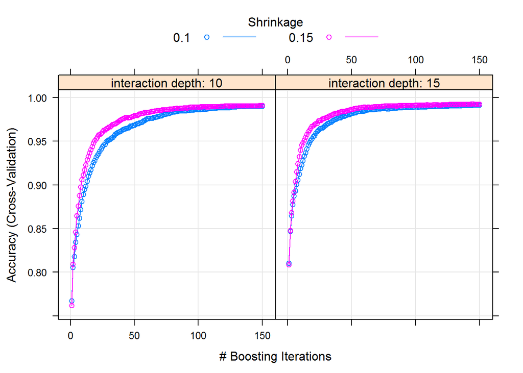

```r
plot(gbm_fit)
```

```r
gbm_varimp <- varImp(gbm_fit)$importance
gbm_o <- order(gbm_varimp[,1], decreasing =TRUE)
kable(gbm_varimp[gbm_o,, drop=FALSE], caption = "GBM Model Variables Importance")
```

GBM Model Variables Importance

|  | Overall |
| --- | --- |
| roll_belt | 100.0000000 |
| yaw_belt | 57.0039642 |
| pitch_forearm | 53.5898387 |
| magnet_dumbbell_z | 47.2256401 |
| pitch_belt | 36.3194341 |
| magnet_dumbbell_y | 30.7592223 |
| roll_forearm | 26.9303424 |
| magnet_belt_z | 23.0192310 |
| gyros_belt_z | 15.6471740 |
| roll_dumbbell | 15.3816745 |
| accel_dumbbell_z | 13.2968847 |
| magnet_dumbbell_x | 13.1399833 |
| accel_dumbbell_y | 12.0613585 |
| yaw_arm | 11.7829825 |
| magnet_forearm_x | 11.5863475 |
| gyros_dumbbell_y | 9.5427447 |
| magnet_belt_x | 9.1457391 |
| magnet_forearm_z | 8.8857296 |
| accel_belt_z | 7.9374100 |
| accel_dumbbell_x | 7.4737578 |
| accel_forearm_x | 6.5465527 |
| magnet_belt_y | 5.7697827 |
| accel_forearm_z | 5.7394961 |
| roll_arm | 5.6455937 |
| magnet_arm_y | 5.2046038 |
| magnet_arm_z | 4.4345693 |
| total_accel_dumbbell | 3.5813312 |
| accel_arm_x | 3.4123928 |
| yaw_forearm | 3.1270758 |
| accel_forearm_y | 2.8547823 |
| gyros_arm_y | 2.8196864 |
| yaw_dumbbell | 2.7830094 |
| gyros_dumbbell_x | 2.5094641 |
| gyros_belt_y | 1.8891276 |
| pitch_dumbbell | 1.7501622 |
| magnet_forearm_y | 1.7063399 |
| magnet_arm_x | 1.6804181 |
| accel_arm_y | 1.1379696 |
| gyros_dumbbell_z | 1.1295157 |
| total_accel_forearm | 0.9823218 |
| pitch_arm | 0.8366178 |
| total_accel_arm | 0.8074646 |
| gyros_forearm_y | 0.7984493 |
| gyros_belt_x | 0.7390869 |
| total_accel_belt | 0.5307555 |
| accel_arm_z | 0.4735452 |
| gyros_forearm_z | 0.4472225 |
| gyros_arm_x | 0.2505595 |
| accel_belt_x | 0.1844364 |
| accel_belt_y | 0.0952158 |
| gyros_forearm_x | 0.0177270 |
| gyros_arm_z | 0.0000000 |

```r
# confusion matrix based on training set
confusionMatrix(predict(gbm_fit, newdata=training_x[data_part,]),
                training[data_part,]$classe)
```

```
## Confusion Matrix and Statistics
##
##           Reference
## Prediction    A    B    C    D    E
##          A 3348    0    0    0    0
##          B    0 2279    0    0    0
##          C    0    0 2054    0    0
##          D    0    0    0 1930    0
##          E    0    0    0    0 2165
##
## Overall Statistics
##
##                Accuracy : 1
##                  95% CI : (0.9997, 1)
##     No Information Rate : 0.2843
##     P-Value [Acc > NIR] : < 2.2e-16
##
##                   Kappa : 1
##  Mcnemar's Test P-Value : NA
##
## Statistics by Class:
##
##                      Class: A Class: B Class: C Class: D Class: E
## Sensitivity            1.0000   1.0000   1.0000   1.0000   1.0000
## Specificity            1.0000   1.0000   1.0000   1.0000   1.0000
## Pos Pred Value         1.0000   1.0000   1.0000   1.0000   1.0000
## Neg Pred Value         1.0000   1.0000   1.0000   1.0000   1.0000
## Prevalence             0.2843   0.1935   0.1744   0.1639   0.1838
## Detection Rate         0.2843   0.1935   0.1744   0.1639   0.1838
## Detection Prevalence   0.2843   0.1935   0.1744   0.1639   0.1838
## Balanced Accuracy      1.0000   1.0000   1.0000   1.0000   1.0000
```

```r
# confusion matrix based on validation set
(gbm_cmat <- confusionMatrix(predict(gbm_fit, newdata=training_x[-data_part,]),
                training[-data_part,]$classe))
```

```
## Confusion Matrix and Statistics
##
##           Reference
## Prediction    A    B    C    D    E
##          A 2231    2    0    0    0
##          B    0 1512    4    3    0
##          C    1    4 1361   11    3
##          D    0    0    3 1267    6
##          E    0    0    0    5 1433
##
## Overall Statistics
##
##                Accuracy : 0.9946
##                  95% CI : (0.9928, 0.9961)
##     No Information Rate : 0.2845
##     P-Value [Acc > NIR] : < 2.2e-16
##
##                   Kappa : 0.9932
##  Mcnemar's Test P-Value : NA
##
## Statistics by Class:
##
##                      Class: A Class: B Class: C Class: D Class: E
## Sensitivity            0.9996   0.9960   0.9949   0.9852   0.9938
## Specificity            0.9996   0.9989   0.9971   0.9986   0.9992
## Pos Pred Value         0.9991   0.9954   0.9862   0.9929   0.9965
## Neg Pred Value         0.9998   0.9991   0.9989   0.9971   0.9986
## Prevalence             0.2845   0.1935   0.1744   0.1639   0.1838
## Detection Rate         0.2843   0.1927   0.1735   0.1615   0.1826
## Detection Prevalence   0.2846   0.1936   0.1759   0.1626   0.1833
## Balanced Accuracy      0.9996   0.9975   0.9960   0.9919   0.9965
```

```r
out_of_sample_err_perc <- round((1 - gbm_cmat$overall[1])*100, 2)
```

The expected out-of-sample error for the GBM model is 0.54 %.

- **Random Forest Model**

The Random Forest model is build with the same number of trees as per GBM. The *tuneLength* parameter is set equal to 10 to drive the *mtry* choice.

```r
rf_fit <- train(x = training_x[data_part,],
                y = training[data_part,]$classe,
                method = "rf",
                preProcess = c("center", "scale", "nzv"),
                trControl = fitControl,
                ntree = 150,
                tuneLength = 10,
                metric = 'Accuracy',
                verbose = FALSE)
rf_fit
```

```
## Random Forest
##
## 11776 samples
##    52 predictor
##     5 classes: 'A', 'B', 'C', 'D', 'E'
##
## Pre-processing: centered (52), scaled (52)
## Resampling: Cross-Validated (10 fold)
## Summary of sample sizes: 10599, 10599, 10599, 10599, 10597, 10598, ...
## Resampling results across tuning parameters:
##
##   mtry  Accuracy   Kappa
##    2    0.9900652  0.9874305
##    7    0.9915092  0.9892590
##   13    0.9918487  0.9896891
##   18    0.9909994  0.9886136
##   24    0.9898106  0.9871091
##   29    0.9893010  0.9864647
##   35    0.9876872  0.9844229
##   40    0.9867529  0.9832408
##   46    0.9840354  0.9798037
##   52    0.9819128  0.9771163
##
## Accuracy was used to select the optimal model using  the largest value.
## The final value used for the model was mtry = 13.
```

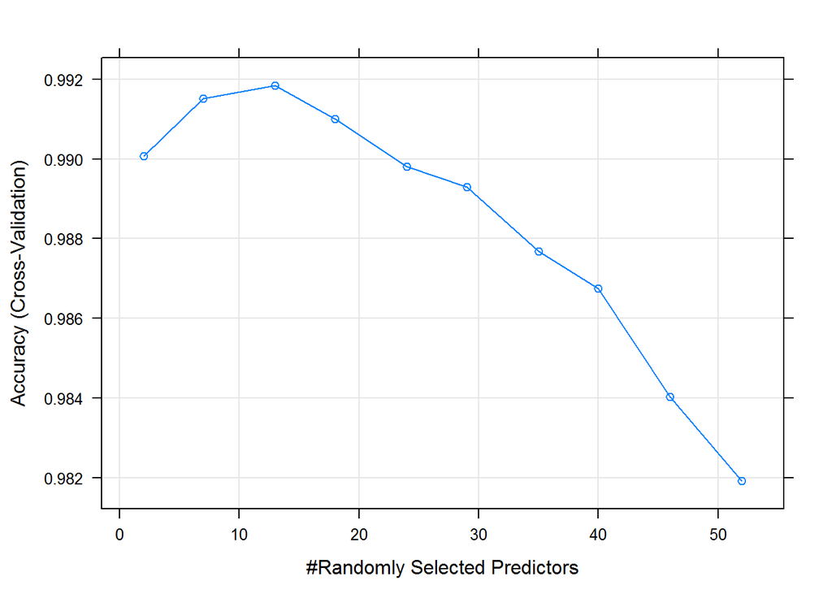

```r
plot(rf_fit)
```

```r
rf_varimp <- varImp(rf_fit)$importance
rf_o <- order(rf_varimp[,1], decreasing =TRUE)
kable(rf_varimp[rf_o,, drop=FALSE], caption = "RF Model Variables Importance")
```

RF Model Variables Importance

|  | Overall |
| --- | --- |
| roll_belt | 100.0000000 |
| yaw_belt | 67.2895763 |
| pitch_forearm | 62.0061106 |
| magnet_dumbbell_z | 53.0247525 |
| pitch_belt | 51.9904441 |
| roll_forearm | 50.5982132 |
| magnet_dumbbell_y | 49.9990692 |
| magnet_dumbbell_x | 27.5406364 |
| roll_dumbbell | 26.2254931 |
| accel_dumbbell_y | 25.8776912 |
| accel_belt_z | 24.1793156 |
| magnet_belt_z | 22.3364786 |
| magnet_belt_y | 21.0133853 |
| accel_dumbbell_z | 18.3530568 |
| accel_forearm_x | 17.9760339 |
| magnet_forearm_z | 17.1400626 |
| total_accel_dumbbell | 15.8089821 |
| gyros_belt_z | 14.5970444 |
| roll_arm | 14.5579659 |
| magnet_belt_x | 14.4409069 |
| yaw_dumbbell | 13.1652783 |
| accel_dumbbell_x | 13.1620772 |
| gyros_dumbbell_y | 12.6250152 |
| accel_arm_x | 12.2348124 |
| yaw_arm | 11.7633852 |
| total_accel_belt | 11.4150340 |
| magnet_arm_x | 11.2923706 |
| magnet_forearm_x | 11.1234605 |
| accel_forearm_z | 10.9829606 |
| magnet_forearm_y | 10.3580838 |
| magnet_arm_y | 9.7550832 |
| magnet_arm_z | 8.5621779 |
| pitch_dumbbell | 7.7499224 |
| yaw_forearm | 7.5583324 |
| pitch_arm | 6.7701534 |
| accel_forearm_y | 5.4693940 |
| accel_arm_y | 5.3754371 |
| gyros_arm_y | 5.1588701 |
| gyros_arm_x | 4.1365131 |
| gyros_dumbbell_x | 3.8801981 |
| gyros_forearm_y | 3.7818732 |
| accel_arm_z | 3.7188985 |
| accel_belt_y | 2.9873072 |
| gyros_belt_x | 2.9649491 |
| accel_belt_x | 2.9404445 |
| total_accel_arm | 2.6685967 |
| gyros_belt_y | 2.3857481 |
| total_accel_forearm | 2.3475751 |
| gyros_dumbbell_z | 1.8599654 |
| gyros_forearm_z | 1.2798763 |
| gyros_forearm_x | 0.4102823 |
| gyros_arm_z | 0.0000000 |

```r
# confusion matrix based on training set
confusionMatrix(predict(rf_fit, newdata=training_x[data_part,]),
                training[data_part,]$classe)
```

```
## Confusion Matrix and Statistics
##
##           Reference
## Prediction    A    B    C    D    E
##          A 3348    0    0    0    0
##          B    0 2279    0    0    0
##          C    0    0 2054    0    0
##          D    0    0    0 1930    0
##          E    0    0    0    0 2165
##
## Overall Statistics
##
##                Accuracy : 1
##                  95% CI : (0.9997, 1)
##     No Information Rate : 0.2843
##     P-Value [Acc > NIR] : < 2.2e-16
##
##                   Kappa : 1
##  Mcnemar's Test P-Value : NA
##
## Statistics by Class:
##
##                      Class: A Class: B Class: C Class: D Class: E
## Sensitivity            1.0000   1.0000   1.0000   1.0000   1.0000
## Specificity            1.0000   1.0000   1.0000   1.0000   1.0000
## Pos Pred Value         1.0000   1.0000   1.0000   1.0000   1.0000
## Neg Pred Value         1.0000   1.0000   1.0000   1.0000   1.0000
## Prevalence             0.2843   0.1935   0.1744   0.1639   0.1838
## Detection Rate         0.2843   0.1935   0.1744   0.1639   0.1838
## Detection Prevalence   0.2843   0.1935   0.1744   0.1639   0.1838
## Balanced Accuracy      1.0000   1.0000   1.0000   1.0000   1.0000
```

```r
# confusion matrix based on validation set
(rf_cmat <- confusionMatrix(predict(rf_fit, newdata=training_x[-data_part,]),
                training[-data_part,]$classe))
```

```
## Confusion Matrix and Statistics
##
##           Reference
## Prediction    A    B    C    D    E
##          A 2232    4    0    0    0
##          B    0 1509    4    0    0
##          C    0    5 1362   21    4
##          D    0    0    2 1263    6
##          E    0    0    0    2 1432
##
## Overall Statistics
##
##                Accuracy : 0.9939
##                  95% CI : (0.9919, 0.9955)
##     No Information Rate : 0.2845
##     P-Value [Acc > NIR] : < 2.2e-16
##
##                   Kappa : 0.9923
##  Mcnemar's Test P-Value : NA
##
## Statistics by Class:
##
##                      Class: A Class: B Class: C Class: D Class: E
## Sensitivity            1.0000   0.9941   0.9956   0.9821   0.9931
## Specificity            0.9993   0.9994   0.9954   0.9988   0.9997
## Pos Pred Value         0.9982   0.9974   0.9784   0.9937   0.9986
## Neg Pred Value         1.0000   0.9986   0.9991   0.9965   0.9984
## Prevalence             0.2845   0.1935   0.1744   0.1639   0.1838
## Detection Rate         0.2845   0.1923   0.1736   0.1610   0.1825
## Detection Prevalence   0.2850   0.1928   0.1774   0.1620   0.1828
## Balanced Accuracy      0.9996   0.9967   0.9955   0.9904   0.9964
```

```r
out_of_sample_err_perc <- round((1 - rf_cmat$overall[1])*100, 2)
```

The expected out-of-sample error for the Random Forest model is 0.61 %.

### Models Comparison

```r
resamps <- resamples(list(GBM = gbm_fit, RF = rf_fit))
summary(resamps)
```

```
##
## Call:
## summary.resamples(object = resamps)
##
## Models: GBM, RF
## Number of resamples: 10
##
## Accuracy
##       Min. 1st Qu. Median   Mean 3rd Qu.   Max. NA's
## GBM 0.9898  0.9909 0.9919 0.9929  0.9949 0.9966    0
## RF  0.9881  0.9900 0.9915 0.9918  0.9938 0.9957    0
##
## Kappa
##       Min. 1st Qu. Median   Mean 3rd Qu.   Max. NA's
## GBM 0.9871  0.9885 0.9898 0.9910  0.9936 0.9957    0
## RF  0.9850  0.9874 0.9893 0.9897  0.9922 0.9946    0
```

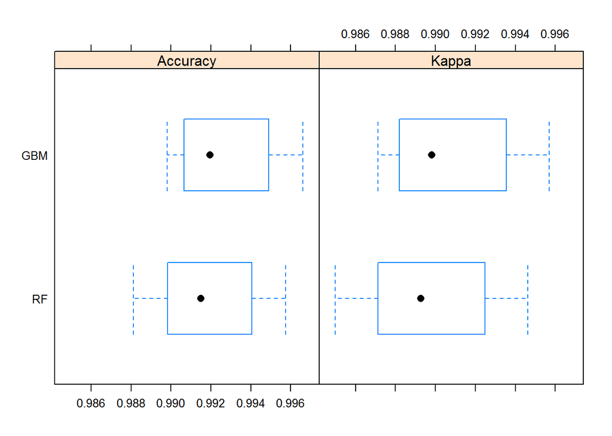

```r
bwplot(resamps, layout = c(2, 1))
```

The GBM model, which has a slightly better accuracy performance than the Random Forest one, is choosen as final model.

### Test Set Predictions

Herein below, required test set predictions are shown.

```r
predict(gbm_fit, har_testing[col_test_names])
```

```
##  [1] B A B A A E D B A A B C B A E E A B B B
## Levels: A B C D E
```

### References

1. [Velloso, E.; Bulling, A.; Gellersen, H.; Ugulino, W.; Fuks, H. Qualitative Activity Recognition of Weight Lifting Exercises. Proceedings of 4th International Conference in Cooperation with SIGCHI (Augmented Human ’13), Stuttgart, Germany: ACM SIGCHI, 2013.](http://groupware.les.inf.puc-rio.br/work.jsf?p1=11201)